# chapter3

Matthias Aulbach

7 Februar 2017

# Exercise 3 - Logistic regression

## loading the data file and checking the structure

```
## 'data.frame':    382 obs. of  35 variables:
##  $ school    : Factor w/ 2 levels "GP","MS": 1 1 1 1 1 1 1 1 1 1 ...
##  $ sex       : Factor w/ 2 levels "F","M": 1 1 1 1 1 2 2 1 2 2 ...
##  $ age       : int  18 17 15 15 16 16 16 17 15 15 ...
##  $ address   : Factor w/ 2 levels "R","U": 2 2 2 2 2 2 2 2 2 2 ...
##  $ famsize   : Factor w/ 2 levels "GT3","LE3": 1 1 2 1 1 2 2 1 2 1 ...
##  $ Pstatus   : Factor w/ 2 levels "A","T": 1 2 2 2 2 2 2 1 1 2 ...
##  $ Medu      : int  4 1 1 4 3 4 2 4 3 3 ...
##  $ Fedu      : int  4 1 1 2 3 3 2 4 2 4 ...
##  $ Mjob      : Factor w/ 5 levels "at_home","health",..: 1 1 1 2 3 4 3 3 4 3 ...
##  $ Fjob      : Factor w/ 5 levels "at_home","health",..: 5 3 3 4 3 3 3 5 3 3 ...
##  $ reason    : Factor w/ 4 levels "course","home",..: 1 1 3 2 2 4 2 2 2 2 ...
##  $ nursery   : Factor w/ 2 levels "no","yes": 2 1 2 2 2 2 2 2 2 2 ...
##  $ internet  : Factor w/ 2 levels "no","yes": 1 2 2 2 1 2 2 1 2 2 ...
##  $ guardian  : Factor w/ 3 levels "father","mother",..: 2 1 2 2 1 2 2 2 2 2 ...
```

[output cut: 21 more lines]

## Printing column names

```
##  [1] "school"     "sex"        "age"        "address"    "famsize"
##  [6] "Pstatus"    "Medu"       "Fedu"       "Mjob"       "Fjob"
## [11] "reason"     "nursery"    "internet"   "guardian"   "traveltime"
## [16] "studytime"  "failures"   "schoolsup"  "famsup"     "paid"
## [21] "activities" "higher"     "romantic"   "famrel"     "freetime"
## [26] "goout"      "Dalc"       "Walc"       "health"     "absences"
## [31] "G1"         "G2"         "G3"         "alc_use"    "high_use"
```

The data set consists of 35 variables with 382 participants. It consists of different information about students in math and Portuguese language courses (see names of the columns).

## Relationship between alcohol consumption and 4 predictors

I will study the relationship between alcohol consumption and the following four variables

1. sex
2. age
3. Pstatus (the cohabitation status of students’ parents)
4. romantic (whether the student is in a romantic relationship or not)

My hypotheses are as follows:

1. Boys are more likely to be heavy alcohol users than girls.
2. Older students drink more than younger students.
3. Students, whose parents live apart drink more than students whose parents live together.
4. Student in a romantic relationship drink less than students without a romantic relationship

## sex vs high_use

```r
sex_high_use <- CrossTable(alc$sex, alc$high_use)
```

```
##
##
##    Cell Contents
## |-------------------------|
## |                       N |
## | Chi-square contribution |
## |           N / Row Total |
## |           N / Col Total |
## |         N / Table Total |
## |-------------------------|
##
##
## Total Observations in Table:  382
##
##
##              | alc$high_use
##      alc$sex |     FALSE |      TRUE | Row Total |
## -------------|-----------|-----------|-----------|
##            F |       157 |        41 |       198 |
##              |     2.078 |     5.009 |           |
##              |     0.793 |     0.207 |     0.518 |
##              |     0.581 |     0.366 |           |
##              |     0.411 |     0.107 |           |
## -------------|-----------|-----------|-----------|
##            M |       113 |        71 |       184 |
##              |     2.236 |     5.390 |           |
##              |     0.614 |     0.386 |     0.482 |
##              |     0.419 |     0.634 |           |
##              |     0.296 |     0.186 |           |
## -------------|-----------|-----------|-----------|
## Column Total |       270 |       112 |       382 |
##              |     0.707 |     0.293 |           |
## -------------|-----------|-----------|-----------|
##
##
```

```r
g1 <- ggplot(alc, aes(x = sex, y = alc_use))
```

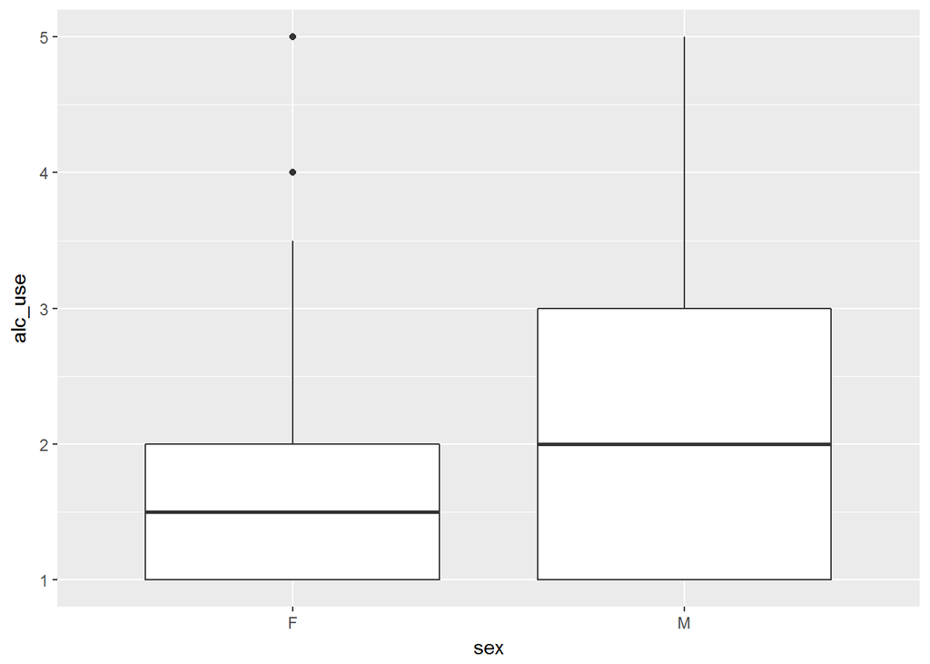

```r
g1 + geom_boxplot() + ylab("alc_use")
```

The boxplot shows that the CIs for males and females overlap largely. On average, males drink more than females.

The hypothesis is supported by the data. Males drink more on average and are more likely to be high users than females.

## age vs high_use

```r
g2 <- ggplot(alc, aes(x = high_use, y = age))
```

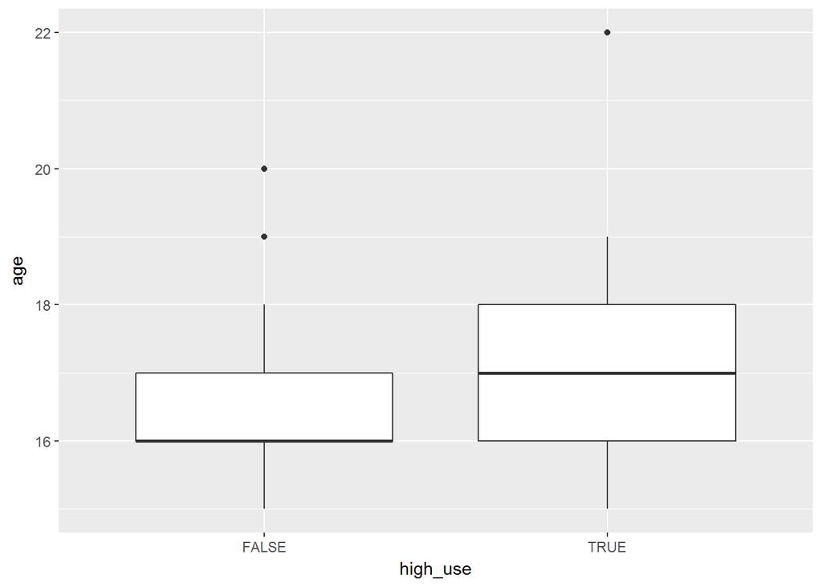

```r
g2 + geom_boxplot() + ylab ("age")
```

```r
reg1 <- lm (alc$alc_use ~ alc$age)
```

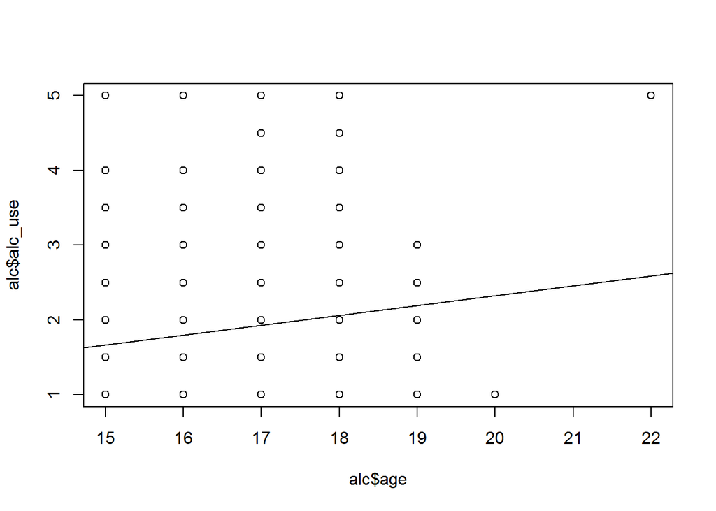

```r
g3 <- plot(alc$alc_use ~ alc$age)
abline (reg1)
```

Judging from the boxplot, high alcohol users are older than non-high-users on average. However, the confidence intervals overlap largely, indicating that there is no significant age difference between high alcohol users and non high alcohol users. The scatterplot alc_use vs age indicates a positive correlation between age and alcohol use. However, the variable alc_use is not truly numeric but rather categorical (even though it says differently in the description of the dataset). Therefore, the correlation doesn’t make much sense.

## Pstatus vs high_use

```r
CrossTable(alc$Pstatus, alc$high_use)
```

```
##
##
##    Cell Contents
## |-------------------------|
## |                       N |
## | Chi-square contribution |
## |           N / Row Total |
## |           N / Col Total |
## |         N / Table Total |
## |-------------------------|
##
##
## Total Observations in Table:  382
##
##
##              | alc$high_use
##  alc$Pstatus |     FALSE |      TRUE | Row Total |
## -------------|-----------|-----------|-----------|
##            A |        26 |        12 |        38 |
##              |     0.027 |     0.066 |           |
##              |     0.684 |     0.316 |     0.099 |
##              |     0.096 |     0.107 |           |
##              |     0.068 |     0.031 |           |
## -------------|-----------|-----------|-----------|
##            T |       244 |       100 |       344 |
##              |     0.003 |     0.007 |           |
##              |     0.709 |     0.291 |     0.901 |
##              |     0.904 |     0.893 |           |
##              |     0.639 |     0.262 |           |
## -------------|-----------|-----------|-----------|
## Column Total |       270 |       112 |       382 |
##              |     0.707 |     0.293 |           |
## -------------|-----------|-----------|-----------|
##
##
```

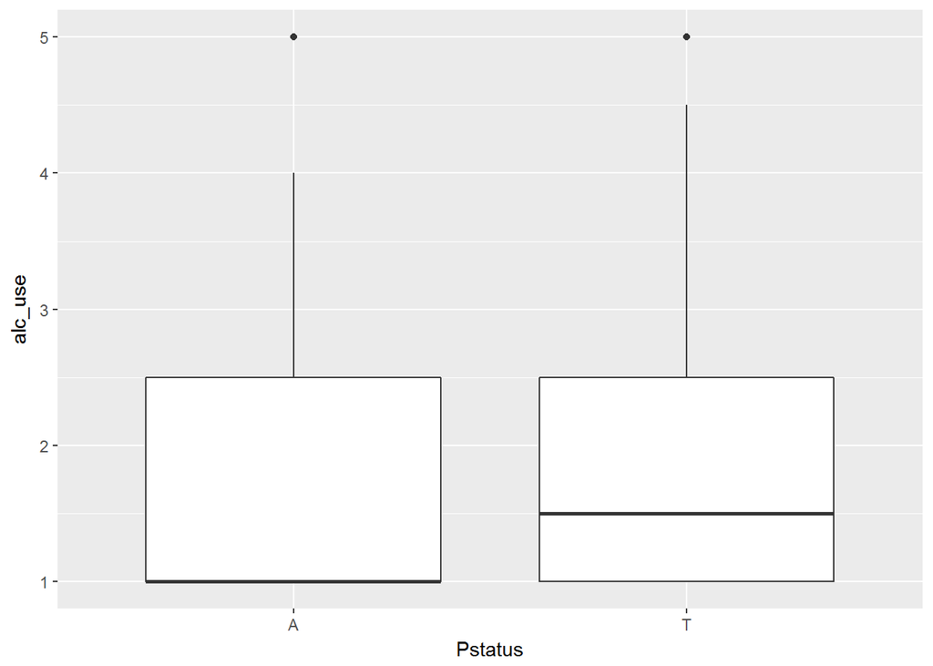

```r
g4 <- ggplot(alc, aes(x = Pstatus, y = alc_use))
g4 + geom_boxplot() + ylab("alc_use")
```

32% of students whose parents live apart are high alcohol users compared to 30% of students whose parents live together are high alcohol users. This indicates no large differences in high alcohol use depending on the parental cohabitation status. In addition, we can see in the boxplot that while the average alcohol consumption is slightly higher for the “together” group, the distributions are very similar in both groups, indicating no differences. The hypothesis is not supported.

## romantic vs high_use

```r
CrossTable(alc$romantic, alc$high_use)
```

```
##
##
##    Cell Contents
## |-------------------------|
## |                       N |
## | Chi-square contribution |
## |           N / Row Total |
## |           N / Col Total |
## |         N / Table Total |
## |-------------------------|
##
##
## Total Observations in Table:  382
##
##
##              | alc$high_use
## alc$romantic |     FALSE |      TRUE | Row Total |
## -------------|-----------|-----------|-----------|
##           no |       182 |        79 |       261 |
##              |     0.033 |     0.080 |           |
##              |     0.697 |     0.303 |     0.683 |
##              |     0.674 |     0.705 |           |
##              |     0.476 |     0.207 |           |
## -------------|-----------|-----------|-----------|
##          yes |        88 |        33 |       121 |
##              |     0.072 |     0.173 |           |
##              |     0.727 |     0.273 |     0.317 |
##              |     0.326 |     0.295 |           |
##              |     0.230 |     0.086 |           |
## -------------|-----------|-----------|-----------|
## Column Total |       270 |       112 |       382 |
##              |     0.707 |     0.293 |           |
## -------------|-----------|-----------|-----------|
##
##
```

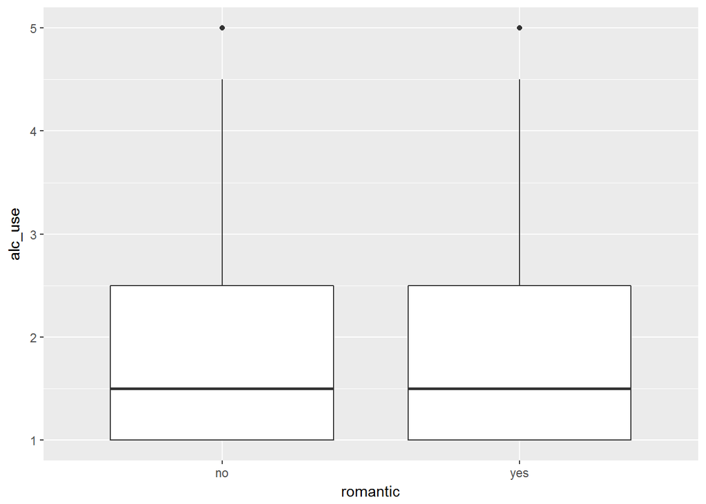

```r
g5 <- ggplot(alc, aes(x = romantic, y = alc_use))

g5 + geom_boxplot() + ylab("alc_use")
```

# Logistic regression

```r
m <- glm (high_use ~ sex + age + Pstatus + romantic, data = alc, family = "binomial")

summary (m)
```

```
##
## Call:
## glm(formula = high_use ~ sex + age + Pstatus + romantic, family = "binomial",
##     data = alc)
##
## Deviance Residuals:
##     Min       1Q   Median       3Q      Max
## -1.4023  -0.8664  -0.6634   1.2355   1.9918
##
## Coefficients:
##             Estimate Std. Error z value Pr(>|z|)
## (Intercept) -4.71264    1.66553  -2.830 0.004662 **
## sexM         0.88897    0.23408   3.798 0.000146 ***
## age          0.21692    0.09864   2.199 0.027874 *
## PstatusT    -0.21649    0.38236  -0.566 0.571257
## romanticyes -0.16035    0.25391  -0.632 0.527685
## ---
## Signif. codes:  0 '***' 0.001 '**' 0.01 '*' 0.05 '.' 0.1 ' ' 1
##
## (Dispersion parameter for binomial family taken to be 1)
##
##     Null deviance: 462.21  on 381  degrees of freedom
## Residual deviance: 442.18  on 377  degrees of freedom
## AIC: 452.18
##
## Number of Fisher Scoring iterations: 4
```

```r
coef(m)
```

```
## (Intercept)        sexM         age    PstatusT romanticyes
##  -4.7126355   0.8889660   0.2169175  -0.2164925  -0.1603532
```

## Odds-Ratios with Confidence Intervals

```r
OR <- coef(m)%>%exp

confint(m)
```

```
##                   2.5 %     97.5 %
## (Intercept) -8.03081816 -1.4826252
## sexM         0.43472494  1.3539681
## age          0.02498304  0.4128488
## PstatusT    -0.94914320  0.5619781
## romanticyes -0.66609321  0.3316545
```

```r
CI <- confint(m) %>% exp
cbind (OR, CI)
```

```
##                      OR       2.5 %    97.5 %
## (Intercept) 0.008981077 0.000325282 0.2270409
## sexM        2.432613009 1.544538157 3.8727624
## age         1.242241671 1.025297727 1.5111165
## PstatusT    0.805338579 0.387072524 1.7541389
## romanticyes 0.851842826 0.513711627 1.3932714
```

Here, I examine how well the model actually predicts high alcohol use.

```r
probabilities <- predict(m, type = "response")

alc <- mutate(alc, probability = probabilities)

alc <- mutate(alc, prediction = probability > 0.5)

table(high_use = alc$high_use, prediction = alc$prediction)
```

```
##         prediction
## high_use FALSE TRUE
##    FALSE   266    4
##    TRUE    108    4
```

Let’s take a closer look at the significant predictors from the model: sex and age

```r
m1 <- glm(high_use ~ sex + age, data = alc, family = "binomial")
probabilities <- predict(m1, type = "response")
alc <- mutate(alc, probability = probabilities)
alc <- mutate(alc, prediction = probability > 0.5)
table(high_use = alc$high_use, prediction = alc$prediction)
```

```
##         prediction
## high_use FALSE TRUE
##    FALSE   265    5
##    TRUE    109    3
```

We can see that this model is - in absolute numbers - worse than the one with more predictors (which is trivial) The number of correct “TRUE” predictions is now only 3 instead of 4. This plot illustrates the inaccuracy of the model prediction:

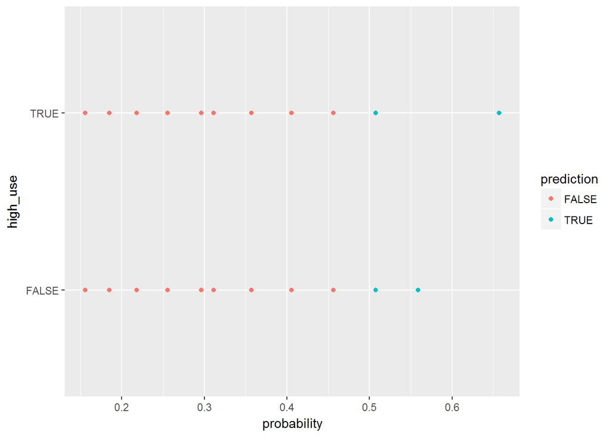

```r
g_m1 <- ggplot(alc, aes(x = probability, y = high_use, col = prediction))
g_m1 + geom_point()
```

## Loss function

```r
table(high_use = alc$high_use, prediction = alc$prediction) %>% prop.table() %>% addmargins()
```

```
##         prediction
## high_use       FALSE        TRUE         Sum
##    FALSE 0.693717277 0.013089005 0.706806283
##    TRUE  0.285340314 0.007853403 0.293193717
##    Sum   0.979057592 0.020942408 1.000000000
```

```r
loss_func <- function(class, prob) {
  n_wrong <- abs(class - prob) > 0.5
  mean(n_wrong)
}

loss_func(class = alc$high_use, prob = alc$probability)
```

```
## [1] 0.2984293
```

In this table and with the help of the loss function we can see that in total ~ 30% of all predictions were incorrect, mostly high users falsely predicted as non high users. Of the remaining 70% correctly classified cases, almost all are correctly classified as “FALSE”. The model is very conservative, avoiding false alarms. Almost 30% of all students are high users. If we had predicted everyone as non high user, the proportion of wrong predictions would have been very similar to what we obtained with the model. The model is therefore not very predictive.

## Cross-validation

```r
library(boot)
cv <- cv.glm(data = alc, cost = loss_func, glmfit = m1, K = 10)
cv$delta[1]
```

```
## [1] 0.2958115
```